# Property Crime Rates: Seattle vs. Chicago

# THEFT

## 1.Problem Domain Description

Seattle, Washington and Chicago, Illinois are some of the most popular destinations for those looking to relocate or for those just looking for a vacation destination. Unfortunately, both cities have faced challenges in being able to mitigate the high rates of property crime plaguing each respective city. According to FindLaw, property crimes are defined as crimes “relating to theft or destruction of someone else’s property”. A few examples of property crimes include (but are not limited to) theft, burglary, robbery, and arson. For the sake of being concise we will focus our dataset on the property crimes mentioned above and we will be analyzing the years of 2018-2019 with one question including data from 2008-2009 as well. We collected our data sets on crime from the [City of Seattle Open Data Portal](https://data.seattle.gov/Public-Safety/Crime-Data/4fs7-3vj5/data) and [City of Chicago Data Portal](https://data.cityofchicago.org/Public-Safety/Crimes-2001-to-present/ijzp-q8t2/data). Are datasets will allow those who live in or intend on frequenting either city to foster a better understanding of the current state of property crime in each city and will allow them to analyze how each city has attempted to curb the high rates affecting the city over time.

### 1.1 Analysis Questions

*Which city has been able to reduce the number of robberies committed in the time period of our dataset?*

This question is significant because it allows us to gauge which city has taken the proper steps to reduce the amount of robberies occurring in each city in a 10-year time span. The datasets will allow us to answer our question by giving us clear indication of which city has been successful in reducing robberies.

*What locations have the highest chance of a crime occuring?*

*What locations have the highest chance of a crime occuring in Chicago?*

This Question is beneficial to others because it provides insight to other individuals, families, and businesses of the type of crimes in Chicago to be aware of. Chicago being one of the most violent cities in the US, theft remains to be the leading factor among gun violence.

*Where is the most frequent neighborhood that each crime is committed in Seattle.*

This question is beneficial to others because it provides insight to other individuals, families, and businesses of the type of crimes in which to be aware of.

*What neighborhoods are the most frequent for each property crime to be commited in Seattle?*

Our team wanted to determine what particular property crime might be most popular in a given neighborhood. We found this question to be important as residents of a particular neighborhood want to be aware of what issues are in their community so that the specific crime (ie theft) can be guarded against and proactively managed.

*During what hour do most bank robberies occur in each city? Is that time consistent with the national average (6pm - 6am)?*

*What date saw the most crimes that happened in Chicago (and Seattle): use weekdays() function for example: weekdays(as.Date(“2020-01-30”)).*

## 2. Data Description

The dataset that we will be using has been collected from the [City of Seattle Open Data Portal](https://data.seattle.gov/Public-Safety/Crime-Data/4fs7-3vj5/data) and [City of Chicago Data Portal](https://data.cityofchicago.org/Public-Safety/Crimes-2001-to-present/ijzp-q8t2/data), the datasets contain the crime incidents that occured in each city from 2018-2019.

- Primary.Type column contains the category of the crime committed
- Description column contains a short explanation of the crime committed
- Precinct column contains the district in which the crime was committed
- IUCR stands for Illinois Uniform Crime Reporting and is the code for the crime committed

**Seattle Raw Data**

| Date | Primary.Type | Description | Location.Description | Precinct |
| --- | --- | --- | --- | --- |
| 1/1/2018 | BURGLARY-RESIDENTIAL | BURGLARY-FORCE-RES | ALASKA JUNCTION | SOUTHWEST |
| ` | THEFT-BUILDING | THEFT-BUILDING | QUEEN ANNE | WEST |
| 1/1/2018 | THEFT-ALL OTHER | THEFT-MAIL | BRIGHTON/DUNLAP | SOUTH |
| 1/1/2018 | BURGLARY-RESIDENTIAL | BURGLARY-FORCE-RES | BALLARD NORTH | NORTH |
| 1/1/2018 | THEFT-BUILDING | THEFT-BUILDING | BALLARD NORTH | NORTH |

**Chicago Raw Data**

| Date | Primary.Type | Description | Location.Description | IUCR |
| --- | --- | --- | --- | --- |
| 02/01/2018 12:00:00 AM | MOTOR VEHICLE THEFT | AUTOMOBILE | STREET | 0910 |
| 02/01/2018 12:00:00 AM | THEFT | OVER $500 | STREET | 0810 |
| 02/01/2018 12:00:00 AM | THEFT | $500 AND UNDER | VEHICLE NON-COMMERCIAL | 0820 |
| 02/01/2018 12:00:00 AM | BURGLARY | FORCIBLE ENTRY | RESIDENCE | 0610 |
| 02/01/2018 12:00:00 AM | BURGLARY | FORCIBLE ENTRY | RESIDENCE | 0610 |

### 2.2 Summary Analysis

#### Chicago Summary Analysis

| Primary.Type | n |
| --- | --- |
| ARSON | 638 |
| BURGLARY | 26102 |
| MOTOR VEHICLE THEFT | 18641 |
| ROBBERY | 16714 |
| THEFT | 87557 |

#### Seattle Summary Analysis

| Crime.Subcategory | n |
| --- | --- |
|  | 183 |
| ARSON | 92 |
| BURGLARY-COMMERCIAL | 2101 |
| BURGLARY-RESIDENTIAL | 4339 |
| CAR PROWL | 12547 |
| MOTOR VEHICLE THEFT | 3632 |
| ROBBERY-COMMERCIAL | 314 |
| ROBBERY-RESIDENTIAL | 94 |
| ROBBERY-STREET | 1178 |
| THEFT-ALL OTHER | 4539 |
| THEFT-BICYCLE | 496 |
| THEFT-BUILDING | 1654 |
| THEFT-SHOPLIFT | 4217 |

## 3. Specific Question Analyses

### *Which city has been able to reduce the number of robberies committed in a 10 year time frame 2008-2009 & 2018-2019?*

Robbery is a form of property crime and there are many different types of robberies. Robbery is defined as taking something from a victim’s person where that person uses or threatens to use, force or violence. We filtered for then combined the different forms of robbery in our data set to summarize the number of robberies in each city in 2008-2009 and 2018-2019. We then took those results and compared them to find out which city was able to reduce the number of robberies after ten years.

[output not shown]

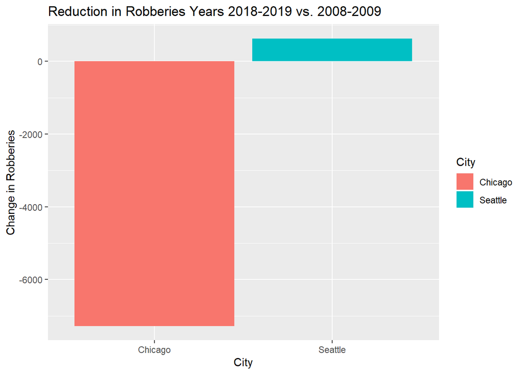

### *What locations have the highest chance of a crime occuring in Chicago?*

As Chicago is known for their crimes, we focused on crime that involved theft of personal property. As you may assume there are areas in Chicago in which are less likely to involve theft. However, in order to prove this I needed to see how often locations that involved in theft also had other reports of theft, therefore I did this by filtering for only acts that involved theft and summarized it by the count in order to determine the number of times thefts occur in reported areas. We then took the results in order to find the top 5 locations in Chicago where robberies are most likely to occur.

[interactive chart not shown]

Given the graph, the top 5 locations in Chicago that have the highest chance of theft, happens to be near their downtown. In between Randolph and Monroe street centered in downtown there appears to be 3 of the top locations of where thefts have occured. However, not to far away ( to the North downtown and Westward of downtown) there are two locations in which theft often occurs in these areas.